# DSM140 Natural Language Processing Coursework

##### 3. Collocations

*Sources of code or/and ideas for this section:*

1. N-grams: class notes (Topic 3)

Here is supportive plot function that acceptc data frame, quantity of columns to be plotted, title of the chart and color of bars - it plots bar charts. I use for collocations frequency visualization.

```python
def plot_collocations(df, qty, title, color):
    df.head(qty).plot(kind = 'bar', figsize  = (15, 8),
                                color = color,
                                fontsize = 12, legend = False)
    plt.title(title, fontsize = 15)
    plt.show()
```

**Bi-grams**:

True news bi-grams

```python
qty = 20 #quantity of top bigrams to be analyzed and later plotted
```

```python
true_news_bigrams = pd.DataFrame((pd.Series(nltk.bigrams(nltk.word_tokenize(true_news))).value_counts()), columns = ["bigrams"])
true_news_bigrams.head(qty)
```

|  | bigrams |
| --- | --- |
| (united, state) | 8575 |
| (white, house) | 7774 |
| (donald, trump) | 6493 |
| (president, donald) | 5908 |
| (north, korea) | 4494 |
| (prime, minister) | 3865 |
| (new, york) | 3691 |
| (said, would) | 2896 |
| (president, barack) | 2894 |
| (islamic, state) | 2752 |
| (trump, said) | 2666 |
| (supreme, court) | 2246 |
| (told, reporter) | 2056 |
| (official, said) | 2038 |
| (last, week) | 1993 |
| (told, reuters) | 1991 |
| (united, nation) | 1911 |
| (national, security) | 1883 |
| (human, right) | 1853 |
| (house, representative) | 1828 |

As per Word cloud, collocations 'united state', 'white house' and 'donald trump' are indeed top 3. Top 20 confirms that half of the true news dataset for sure belongs to the subject of politics. Yet, I find it interesting that only 'human right' and 'united nation' are collocations that can be from non-politics news.

Here is visual rerpresentation of the top 20 bigrams of true news dataset:

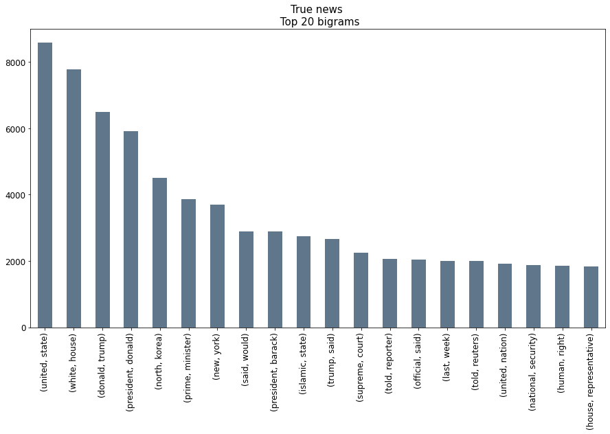

```python
title = "True news \n Top " + str(qty) + " bigrams"
plot_collocations(true_news_bigrams, qty, title, colours_class[1])
```

Fake news bi-grams:

```python
fake_news_bigrams = pd.DataFrame((pd.Series(nltk.bigrams(nltk.word_tokenize(fake_news))).value_counts()), columns = ["bigrams"])
fake_news_bigrams.head(qty)
```

|  | bigrams |
| --- | --- |
| (donald, trump) | 13442 |
| (image, via) | 6194 |
| (hillary, clinton) | 5752 |
| (white, house) | 5093 |
| (united, state) | 4245 |
| (new, york) | 3879 |
| (president, obama) | 3477 |
| (president, trump) | 3381 |
| (fox, news) | 2977 |
| (21st, century) | 2185 |
| (century, wire) | 1892 |
| (trump, supporter) | 1889 |
| (barack, obama) | 1862 |
| (can, not) | 1793 |
| (supreme, court) | 1636 |
| (national, security) | 1502 |
| (black, life) | 1461 |
| (trump, campaign) | 1454 |
| (obama, administration) | 1424 |
| (fake, news) | 1421 |

Here is a visual representation:

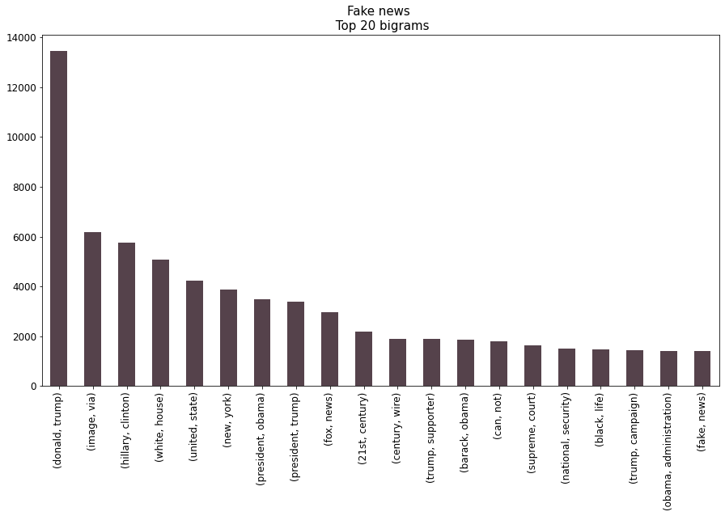

```python
title = "Fake news \n Top " + str(qty) + " bigrams"
plot_collocations(fake_news_bigrams, qty, title, colours_class[0])
```

**Tri-grams**:

Tri-grams for true news data set:

```python
qty = 10 #quantity of top trigrams to be analyzed and later plotted
```

```python
true_news_trigrams = pd.DataFrame((pd.Series(nltk.ngrams(nltk.word_tokenize(true_news), 3)).value_counts()), columns = ["trigrams"])
true_news_trigrams.head(qty)
```

|  | trigrams |
| --- | --- |
| (president, donald, trump) | 3792 |
| (president, barack, obama) | 1353 |
| (washington, president, donald) | 1085 |
| (white, house, said) | 752 |
| (secretary, state, rex) | 652 |
| (former, president, barack) | 630 |
| (russian, president, vladimir) | 599 |
| (prime, minister, theresa) | 583 |
| (president, vladimir, putin) | 566 |
| (state, rex, tillerson) | 532 |

Tri-grams top again confirms the constant persence of politics in news. Mostly it consists of politicians names and titles. 'president donald trump' outperforms the next most frequent collocation by 2.5 times.

Visualization of the table:

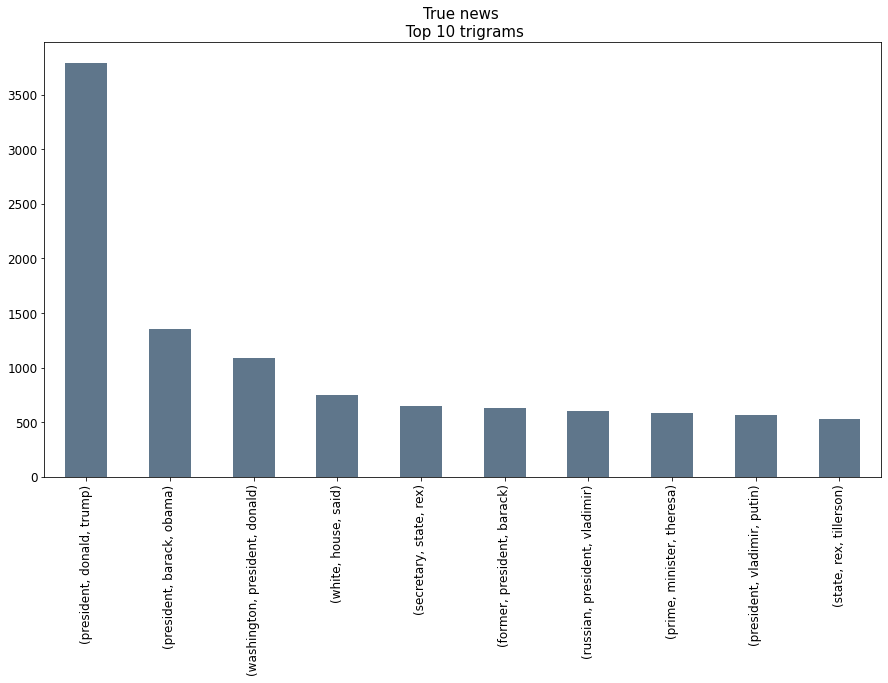

```python
title = "True news \n Top " + str(qty) + " trigrams"
plot_collocations(true_news_trigrams, qty, title, colours_class[1])
```

For fake news:

```python
fake_news_trigrams = pd.DataFrame((pd.Series(nltk.ngrams(nltk.word_tokenize(fake_news), 3)).value_counts()), columns = ["trigrams"])
fake_news_trigrams.head(qty)
```

|  | trigrams |
| --- | --- |
| (21st, century, wire) | 1868 |
| (new, york, time) | 1168 |
| (black, life, matter) | 1154 |
| (news, 21st, century) | 948 |
| (image, via, video) | 787 |
| (president, donald, trump) | 759 |
| (century, wire, say) | 725 |
| (president, barack, obama) | 702 |
| (video, screen, capture) | 680 |
| (via, video, screen) | 668 |

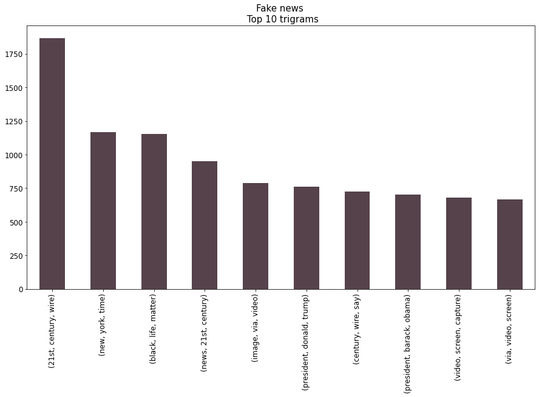

```python
title = "Fake news \n Top " + str(qty) + " trigrams"
plot_collocations(fake_news_trigrams, qty, title, colours_class[0])
```

## 4. Naive Bayes Classifier: implementation

##### Overall, the process of NBC implemeation includes the follwoing steps:

1. Initializing X (features) and Y (labels).
2. Splitting dataset into training and tets sets.
3. Features extraction (vectorization).
4. Model creation
5. Fit model on the training data
6. Predict
1. Initializing X (features) and Y (labels).

```python
X = dataset["text"].tolist()
Y = dataset["class"].tolist()
```

1. Features extraction (vectorization).

```python
vect = TfidfVectorizer().fit(X)
X_vect = vect.transform(X)
X_vect
```

```
<44800x79433 sparse matrix of type '<class 'numpy.float64'>'
	with 6092344 stored elements in Compressed Sparse Row format>
```

1. Splitting dataset into training and tets sets.

```python
# I keep indices in order to retrieve news from the original dataset later
indices = np.arange(X_vect.shape[0])
X_train, X_test, y_train, y_test, idx1, idx2 = train_test_split (X_vect, Y, indices)
```

1. Model initialization

```python
model = MultinomialNB()
```

1. Fit model on the training data

```python
model.fit(X_train, y_train)
```

```
MultinomialNB(alpha=1.0, class_prior=None, fit_prior=True)
```

1. Predict

```python
y_pred = model.predict(X_test)
```

# III. CONCLUSION

## 1. Evaluation

### 1. Accuracy, precision, recall

Before moving to calculation of metrics, I store indecies of wrogly predicted data samples:

```python
indecies_wrongly_predicted_fake = [] #store indecies of true news predicted as fake
indecies_wrongly_predicted_true = [] #store indecies of fake news predicted as true

#loop through the prediction and test vectors
for i in range(len(y_pred)):
    if y_pred[i]==0 and y_test[i]==1:
        indecies_wrongly_predicted_fake.append(i)
    if y_pred[i]==1 and y_test[i]==0:
        indecies_wrongly_predicted_true.append(i)
```

Main metrics clculation:

```python
accuracy = metrics.accuracy_score(y_test, y_pred) * 100
precision = metrics.precision_score(y_test, y_pred) * 100
recall = metrics.recall_score(y_test, y_pred) * 100
f1_score = metrics.f1_score(y_test, y_pred) * 100

print("Accuracy overall: ", np.round(accuracy, 2), "%")
print("Precision: ", np.round(precision, 2), "%")
print("Recall: ", np.round(recall, 2), "%")
print("F1 score: ", np.round(f1_score, 2), "%")
```

```
Accuracy overall:  93.52 %
Precision:  93.55 %
Recall:  94.16 %
F1 score:  93.86 %
```

**Accuracy comment**:

I think that 93.52% accuracy is quite good accomplishment for the purpose of academic reseatrch, however I assume that for real life applications it is not enough. As I mentioned before, nowdays society is very sensetive to the information online and sometimews misinfirmation leads to undoresicted consequences, hence, from real life application I would expect 97-98%+ accuracy.

**Precision comment**:

This metric shows that in 93.55% of cases news predicted as Fake are really Fake, and hence 7% of news predicted as Fake are actually true.

**Recall comment**:

Recall value is especially important for this task performance evalution as it is focused on positive class prediction. For this mode is quite high and shows that 94.16% of fake news are regonized by the model and predicted correctly.

**F1 score comment**:

F1 score is a harmonic mean of pecision and recall, for this model both precision and recal were high, so very logically that it reaches 93.86%.

### 2. Confusion matrix

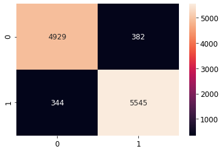

```python
conf_matrix = metrics.confusion_matrix(y_test, y_pred)
sns.heatmap(conf_matrix, annot = conf_matrix, fmt="d")
```

```python
print("Accuracy of class 0 prediction",np.round((len(y_pred)-len(indecies_wrongly_predicted_true))*100/len(y_pred), 2), "%")
print("Accuracy of class 1 prediction",np.round((len(y_pred)-len(indecies_wrongly_predicted_fake))*100/len(y_pred), 2), "%")
```

```
Accuracy of class 0 prediction 96.59 %
Accuracy of class 1 prediction 96.93 %
```

**Confusion matrix comment**:

Confusion matrix confirms precision and recall (recall > precision) numbers:

### 3. Incorrect predictions illustration

```python
qty = 1 # quantity of news to display
```

```python
# function that take index array, quantity of news to display and vectorixer instance,
# it decodes sparse matrices and print out mispredicted news along with bag of words for this news (for sanity check)
# printed results function also returns in respective arrays

def demonstrate_n_decode(indecies, qty, vectorizer):

    wrongly_predicted_news = []
    predicted_labels = []
    true_labels = []


    for i in range(qty):
        ind = indecies[i]

        wrongly_predicted_news.append(X_test[ind])
        predicted_labels.append(y_pred[ind])
        true_labels.append(y_test[ind])

        print("True label:",y_test[ind],"predicted label:",y_pred[ind])
        print("\n")
        print("Bag of words for the news:")
        print(vectorizer.inverse_transform(X_test[ind]))
        print("\n")
        print("News itself:")
        print(X[idx2[ind]])
        print("\n")

    return wrongly_predicted_news, predicted_labels, true_labels
```

#### 3.1. True predicted as fake

```python
wrongly_predicted_true_news, predicted_labels0, true_labels0 = demonstrate_n_decode(indecies_wrongly_predicted_true, qty, vect)
```

```
True label: 0 predicted label: 1


Bag of words for the news:
[array(['york', 'wrong', 'week', 'wallace', 'voter', 'vote', 'unfair',
       'two', 'tuesday', 'trump', 'treatment', 'tougher', 'state',
       'stacked', 'show', 'said', 'respond', 'request', 'republican',
       'repeatedly', 'registered', 'record', 'recent', 'raddatz',
       'primary', 'pressure', 'presidential', 'phony', 'party',
       'otherwise', 'next', 'news', 'new', 'nbc', 'monday', 'moderator',
       'moderate', 'may', 'matt', 'martha', 'lester', 'lauer',
       'journalist', 'interview', 'information', 'host', 'holt',
       'hillary', 'heavily', 'gotten', 'giving', 'fox', 'fourth', 'forum',
       'first', 'fellow', 'election', 'donald', 'district', 'democratic',
       'democrat', 'defense', 'debate', 'critic', 'could', 'cooper',
       'conducting', 'comment', 'cnn', 'clinton', 'chris', 'call',
       'board', 'bill', 'anderson', 'anchor', 'also', 'adding', 'accused',
       'according', 'abc'], dtype='<U130')]


News itself:
trump call first debate moderator record show otherwise republican donald trump may gotten wrong said moderator first presidential debate next week democratic hillary lester moderate debate registered according voter information new york state board election nbc respond request comment tuesday party…
```

**Comment**:

I might be wrong, but taking into consideration that collocations 'donald trump' and 'fox news' occur in this news several times and are in top bi-grams of fake news datset (the first was mentioned more than 13K times!), I find it quite logical that this news has been classified as fake.

#### 3.2. Fake predicted as true

```python
wrongly_predicted_fake_news, predicted_labels1, true_labels1 = demonstrate_n_decode(indecies_wrongly_predicted_fake, qty, vect)
```

```
True label: 1 predicted label: 0


Bag of words for the news:
[array(['workplace', 'week', 'wave', 'video', 'used', 'undocumented',
       'trump', 'threat', 'term', 'targeting', 'targeted', 'talking',
       'substantially', 'state', 'spokeswoman', 'south', 'social',
       'similar', 'show', 'shopping', 'serious', 'series', 'security',
       'scope', 'say', 'said', 'safety', 'routine', 'roadway', 'rest',
       'reporter', 'reported', 'released', 'random', 'raided', 'raid',
       'public', 'prioritizing', 'president', 'prefers', 'post', 'policy',
       'pledged', 'percent', 'people', 'part', 'parking', 'oversees',
       'order', 'operation', 'official', 'offense', 'obama', 'noting',
       'north', 'night', 'new', 'netting', 'netted', 'murder', 'month',
       'monday', 'misdemeanor', 'minor', 'million', 'medium', 'marked',
       'marin', 'majority', 'made', 'los', 'living', 'least', 'latin',
       'last', 'known', 'integrity', 'including', 'include',
       'immigration', 'immigrant', 'illegal', 'id', 'ice', 'hundred',
       'homeland', 'home', 'gillian', 'friday', 'found', 'focus', 'first',
       'finding', 'field', 'felony', 'estimated', 'entire', 'enforcement',
       'ended', 'dozen', 'domestic', 'dislike', 'director', 'detaining',
       'detained', 'deporting', 'deported', 'deportation', 'deport',
       'departure', 'department', 'denied', 'dangerous', 'custom',
       'criminal', 'crackdown', 'crack', 'corral', 'conviction',
       'convicted', 'confirmed', 'conference', 'conducting', 'conduct',
       'committed', 'circulated', 'christensen', 'checkpoint', 'change',
       'center', 'carolina', 'call', 'broadening', 'began', 'authority',
       'austin', 'arrested', 'approximately', 'appeared', 'apparent',
       'angeles', 'american', 'also', 'aimed', 'agent', 'advocate',
       'administration', '75', '37', '26', '160', '11'], dtype='<U130')]


News itself:
president illegal immigrant crackdown conduct raid least 6 state focus finding deporting criminal immigration authority arrested hundred undocumented immigrant least state week series raid marked first enforcement president trump 26 order crack estimated 11 million immigrant living official said tar…
```

While first situation is fine, here is a problem that we target to minimize - fake news classified as true. I have no suggestions why it is like that by just reading the news, however find it disturbing considering it discusses quite sensetive and hot topic - immigrants.

## 2. Conclusion comments

I found really helpful that dataset consists of valid samples of true and fake news. It enables to explore the content easier and make meaningful comments on various outcomes, icnluding statistics metrics. Dataset was balanced and diverse in terms of used lexical resources, and I think it was what contributed a lot to quite high model performace. Reached accuracy of 93% is high for academic purposes and meet the baseline that was set up in evaluation strategy. I did not spot weak sides of the dataset, but I think that there are several things in my work that can be improved, yet they are out of this course work scope:

- implemet several models of different classifiers (e.g. Logistic regression, Neural Networks, Multinomial Naive Bayes Classifier), tune hyperparametrs and then choose the best
- use gensim and glove libraries for deeper dataset analytics (word2vec, word embeddings and synsets analyses)
- match predictions with original news in the condition it was at moment of dataset loading - I managed to matched only with cleaned news.